# lifewatt MVP

AI 算力设施周边社区健康探索 · Gainesville 案例

输入一个设施位置，查询周边社区、查看真实健康数据、比较距离分组并导出表格。 本地快照包含 **58 个社区**，全部成功匹配到官方 Census 地区编码； 以示例地址点为中心，10 公里内选中 **29 个社区**。

## 这个 MVP 已经做了什么

1. 匹配佛州官方 2020–2024 年社区全因死亡率与死亡人数。
2. 按设施地址点到 Census 社区内部代表点的球面距离筛选。
3. 显示社区地图、距离散点图和分组描述表。
4. 导出 CSV，并保留数据时期、来源和查询坐标。
5. 将县级寿命背景独立展示。

安装后的示例可离线运行。当前数据只覆盖 Alachua County；函数可以接受其他地点， 但其他地区需要提供经过核实的同结构社区数据。

## 示例设施与数据时期

| 项目 | 内容 |
| --- | --- |
| 设施 | UF HiPerGator AI / East Campus Data Center |
| 地址点经度 | -82.29854 |
| 地址点纬度 | 29.67147 |
| 坐标方法 | Census 街道地址插值，非建筑实测坐标 |
| AI 系统时期 | UF 官方记载 HiPerGator AI 为 2021 年系统 |
| 社区健康时期 | 2020–2024 年合并值 |
| 地理边界 | 2020 Census tract |

这里展示的是**社区健康背景**。粗死亡率不等于预期寿命，距离不等于污染暴露。 五年窗口跨过 AI 系统扩建时期，且尚未调整年龄、收入、其他设施和空间相关性； 图表不能解释为算力中心造成了健康损害或改善。

## 社区地图

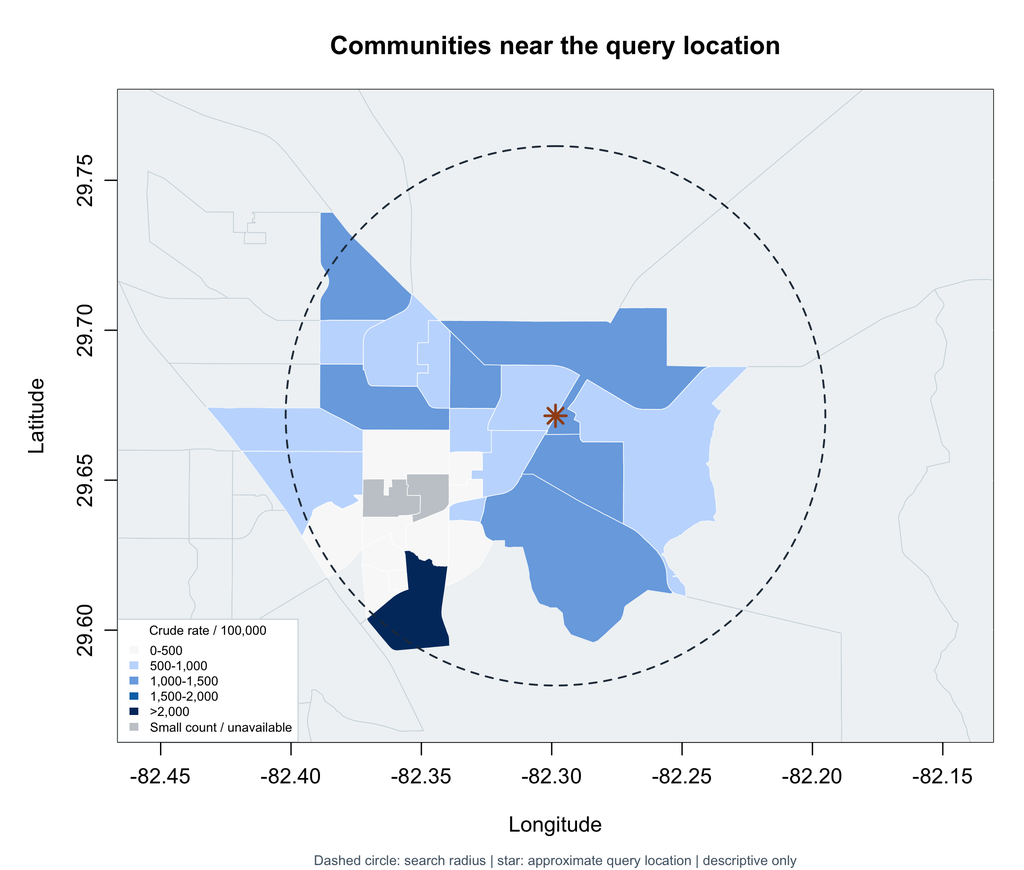

星号为近似设施地址点；虚线为查询半径。选择规则采用社区内部代表点， 社区多边形可能跨过圆圈。灰色背景为未选中的区域；小样本选中区域也显示为灰色。 颜色仅表示官方公布的粗死亡率，不能作为 AI 风险等级。

## 距离与社区指标

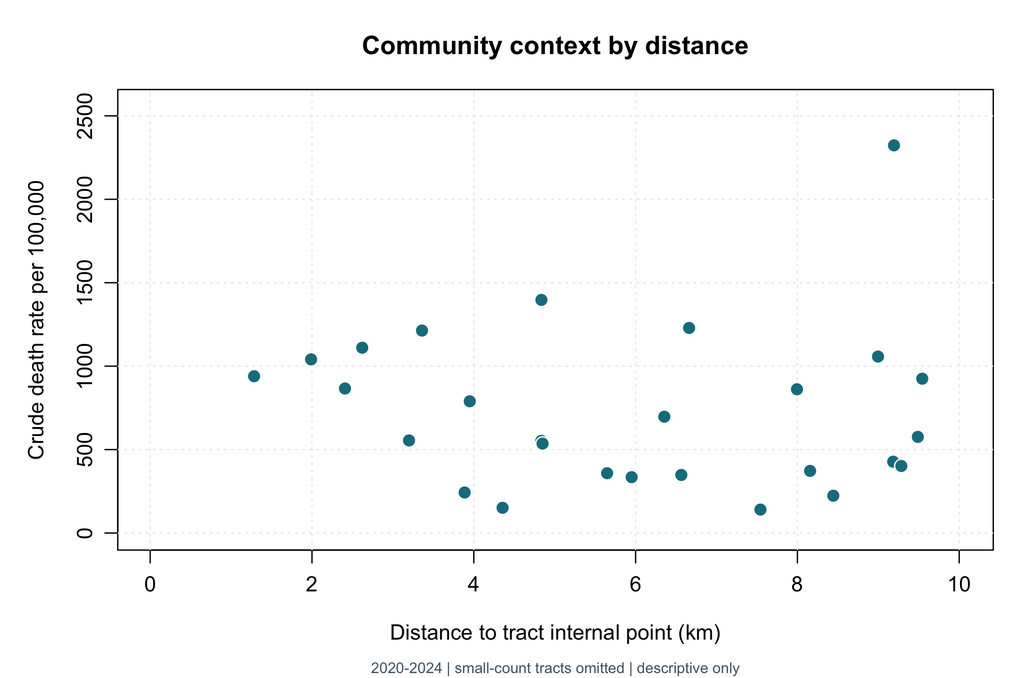

| 距离区间 km | 社区数 | 可用数 | 排除数 | 社区率中位数 | 最小值 | 最大值 |
| --- | --- | --- | --- | --- | --- | --- |
| [0,3] | 4 | 4 | 0 | 990.1 | 866.0 | 1110.6 |
| (3,5] | 8 | 8 | 0 | 553.5 | 151.2 | 1397.1 |
| (5,10] | 17 | 15 | 2 | 427.5 | 140.5 | 2323.2 |
| (10,Inf] | 0 | 0 | 0 | NA | NA | NA |

汇总是各社区粗死亡率的**不加权分布**，不是合并人口后的死亡率。 少于 5 例死亡或死亡人数缺失的社区默认不参与数值汇总。 全县快照中有 2 个小样本社区，原始值仍保留在 CSV 中。

## 最近的社区

| GEOID | 社区编号 | 距离 km | 粗死亡率 / 10万人 | 2020–2024 死亡人数 | 小样本 |
| --- | --- | --- | --- | --- | --- |
| 12001000400 | 4 | 1.28 | 939.7 | 268 | FALSE |
| 12001000600 | 6 | 1.99 | 1040.6 | 277 | FALSE |
| 12001000500 | 5 | 2.41 | 866.0 | 211 | FALSE |
| 12001001902 | 19.02 | 2.62 | 1110.6 | 215 | FALSE |
| 12001000301 | 3.01 | 3.20 | 554.7 | 114 | FALSE |
| 12001000302 | 3.02 | 3.36 | 1213.2 | 145 | FALSE |
| 12001000201 | 2.01 | 3.89 | 242.8 | 57 | FALSE |
| 12001001400 | 14 | 3.95 | 789.6 | 173 | FALSE |
| 12001000202 | 2.02 | 4.36 | 151.2 | 39 | FALSE |
| 12001001203 | 12.03 | 4.83 | 552.2 | 106 | FALSE |
| 12001000700 | 7 | 4.84 | 1397.1 | 480 | FALSE |
| 12001000806 | 8.06 | 4.85 | 536.0 | 89 | FALSE |

## 县级寿命背景

| 地区 | 时期 | 预期寿命年 | 下限 | 上限 |
| --- | --- | --- | --- | --- |
| Alachua | 2022-2024 | 78.9 | 78.5 | 79.2 |

这项县级指标未复制到社区，也不用于比较设施附近 1 公里与 10 公里的居民寿命。

## 在 RStudio 中复现

```r
install.packages("remotes") # 已安装时跳过
remotes::install_github("RePinkert/PHC6099-final-project",
                        ref="mvp-community-health", build_vignettes=FALSE)
library(lifewatt)
f <- example_facility()
p <- nearby_communities(f$longitude, f$latitude, radius_km=10)
plot_communities(p)
compare_communities(p)
export_communities(p,"nearby_communities.csv")
```

安装需要联网，完成后示例可离线运行。把半径改成 3 或 5 可以重新查询。 当前示例不要求 API key。 `demo/run_demo.R` 可重新生成 CSV 和图像。

## 来源与下一步

- [佛州卫生部门社区数据](https://www.flhealthcharts.gov/ChartsDashboards/rdPage.aspx?rdReport=ChartsMaps.ChartsMapper)：全因死亡人数与粗死亡率，2020–2024。
- [Census TIGERweb](https://tigerweb.geo.census.gov/arcgis/rest/services/Census2020/tigerWMS_Census2020/MapServer/6)：2020 社区边界、编码、内部代表点和人口。
- [佛州县级寿命](https://www.flhealthcharts.gov/ChartsDashboards/rdPage.aspx?rdReport=ChartsMaps.LifeExpectancyReport)：Alachua，2022–2024。
- [UF 系统发展说明](https://news.ufl.edu/2025/05/the-fourth-generation-model-of-ufs-hipergator/)：AI 设施身份与时期。

下一步优先核实建筑位置、引入适合的年龄和社会经济数据，再考虑其他设施案例。 目前没有污染测量、AI 因果效应、电价模块或月度寿命趋势。

本地 MVP 的代码与文档使用了 Codex 辅助开发。两位组员需要共同检查数据定义、 理解各自负责的代码，并在课程报告中透明说明 AI 使用情况。